# Analyzing Marketing Campaigns with pandas

## Project: Analyzing Marketing Campaigns

### Introduction:

> this a marketing dataset based on the data of an online subscription business.

> **the question(s) that posed that I am trying to know** :
> - "How did this campaign perform?"
> - "Which channel is referring the most subscribers
> - "Why is a particular channel underperforming?"

```python
import pandas as pd
import numpy as np
import matplotlib.pyplot as plt
import seaborn as sb


marketing = pd.read_csv('marketing.csv', parse_dates= ['date_served', 'date_subscribed','date_canceled'])
marketing.head()
```

|  | user_id | date_served | marketing_channel | variant | converted | language_displayed | language_preferred | age_group | date_subscribed | date_canceled | subscribing_channel | is_retained |
| --- | --- | --- | --- | --- | --- | --- | --- | --- | --- | --- | --- | --- |
| 0 | a100000029 | 2018-01-01 | House Ads | personalization | True | English | English | 0-18 years | 2018-01-01 | NaT | House Ads | True |
| 1 | a100000030 | 2018-01-01 | House Ads | personalization | True | English | English | 19-24 years | 2018-01-01 | NaT | House Ads | True |
| 2 | a100000031 | 2018-01-01 | House Ads | personalization | True | English | English | 24-30 years | 2018-01-01 | NaT | House Ads | True |
| 3 | a100000032 | 2018-01-01 | House Ads | personalization | True | English | English | 30-36 years | 2018-01-01 | NaT | House Ads | True |
| 4 | a100000033 | 2018-01-01 | House Ads | personalization | True | English | English | 36-45 years | 2018-01-01 | NaT | House Ads | True |

```python
# Check column data types and non-missing values
print(marketing.info())
```

```
<class 'pandas.core.frame.DataFrame'>
RangeIndex: 10037 entries, 0 to 10036
Data columns (total 12 columns):
 #   Column               Non-Null Count  Dtype
---  ------               --------------  -----
 0   user_id              10037 non-null  object
 1   date_served          10021 non-null  datetime64[ns]
 2   marketing_channel    10022 non-null  object
 3   variant              10037 non-null  object
 4   converted            10022 non-null  object
 5   language_displayed   10037 non-null  object
 6   language_preferred   10037 non-null  object
 7   age_group            10037 non-null  object
 8   date_subscribed      1856 non-null   datetime64[ns]
 9   date_canceled        577 non-null    datetime64[ns]
 10  subscribing_channel  1856 non-null   object
 11  is_retained          1856 non-null   object
dtypes: datetime64[ns](3), object(9)
memory usage: 941.1+ KB
None
```

```python
# Print the statistics of all columns
marketing.describe()
```

|  | user_id | date_served | marketing_channel | variant | converted | language_displayed | language_preferred | age_group | date_subscribed | date_canceled | subscribing_channel | is_retained |
| --- | --- | --- | --- | --- | --- | --- | --- | --- | --- | --- | --- | --- |
| count | 10037 | 10021 | 10022 | 10037 | 10022 | 10037 | 10037 | 10037 | 1856 | 577 | 1856 | 1856 |
| unique | 7309 | 31 | 5 | 2 | 2 | 4 | 4 | 7 | 31 | 115 | 5 | 2 |
| top | a100000882 | 2018-01-15 00:00:00 | House Ads | control | False | English | English | 19-24 years | 2018-01-16 00:00:00 | 2018-04-02 00:00:00 | Instagram | True |
| freq | 12 | 789 | 4733 | 5091 | 8946 | 9793 | 9275 | 1682 | 163 | 15 | 600 | 1279 |
| first | NaN | 2018-01-01 00:00:00 | NaN | NaN | NaN | NaN | NaN | NaN | 2018-01-01 00:00:00 | 2018-01-05 00:00:00 | NaN | NaN |
| last | NaN | 2018-01-31 00:00:00 | NaN | NaN | NaN | NaN | NaN | NaN | 2018-01-31 00:00:00 | 2018-05-09 00:00:00 | NaN | NaN |

```python
marketing['subscribing_channel'].unique()
```

```
array(['House Ads', 'Email', 'Push', 'Facebook', 'Instagram', nan],
      dtype=object)
```

```python
# Mapping for channels
channel_dict = {"House Ads": 1, "Instagram": 2,
                "Facebook": 3, "Email": 4, "Push": 5}

# Map the channel to a channel code
marketing['channel_code'] = marketing['subscribing_channel'].map(channel_dict)


# Add the new column is_correct_lang
marketing['is_correct_lang'] = np.where(marketing['language_preferred'] == marketing['language_displayed'],'Yes','No')
```

```python
# Add a DoW column
marketing['DoW'] = marketing['date_subscribed'].dt.dayofweek
```

```python
marketing.head(2)
```

|  | user_id | date_served | marketing_channel | variant | converted | language_displayed | language_preferred | age_group | date_subscribed | date_canceled | subscribing_channel | is_retained | channel_code | is_correct_lang | DoW |
| --- | --- | --- | --- | --- | --- | --- | --- | --- | --- | --- | --- | --- | --- | --- | --- |
| 0 | a100000029 | 2018-01-01 | House Ads | personalization | True | English | English | 0-18 years | 2018-01-01 | NaT | House Ads | True | 1.0 | Yes | 0.0 |
| 1 | a100000030 | 2018-01-01 | House Ads | personalization | True | English | English | 19-24 years | 2018-01-01 | NaT | House Ads | True | 1.0 | Yes | 0.0 |

```python
# Import marketing.csv with date columns
marketing = pd.read_csv('marketing.csv', parse_dates= ['date_served', 'date_subscribed','date_canceled'])

# Add a DoW column
marketing['DoW'] = marketing['date_subscribed'].dt.dayofweek
marketing
```

|  | user_id | date_served | marketing_channel | variant | converted | language_displayed | language_preferred | age_group | date_subscribed | date_canceled | subscribing_channel | is_retained | DoW |
| --- | --- | --- | --- | --- | --- | --- | --- | --- | --- | --- | --- | --- | --- |
| 0 | a100000029 | 2018-01-01 | House Ads | personalization | True | English | English | 0-18 years | 2018-01-01 | NaT | House Ads | True | 0.0 |
| 1 | a100000030 | 2018-01-01 | House Ads | personalization | True | English | English | 19-24 years | 2018-01-01 | NaT | House Ads | True | 0.0 |
| 2 | a100000031 | 2018-01-01 | House Ads | personalization | True | English | English | 24-30 years | 2018-01-01 | NaT | House Ads | True | 0.0 |
| 3 | a100000032 | 2018-01-01 | House Ads | personalization | True | English | English | 30-36 years | 2018-01-01 | NaT | House Ads | True | 0.0 |
| 4 | a100000033 | 2018-01-01 | House Ads | personalization | True | English | English | 36-45 years | 2018-01-01 | NaT | House Ads | True | 0.0 |
| ... | ... | ... | ... | ... | ... | ... | ... | ... | ... | ... | ... | ... | ... |
| 10032 | a100007290 | 2018-01-17 | Email | control | True | German | German | 45-55 years | 2018-01-17 | 2018-01-24 | Email | False | 2.0 |
| 10033 | a100007291 | 2018-01-17 | Email | control | True | German | German | 55+ years | 2018-01-17 | NaT | Email | True | 2.0 |
| 10034 | a100007292 | 2018-01-05 | Instagram | control | False | German | German | 55+ years | 2018-01-17 | NaT | Email | True | 2.0 |
| 10035 | a100007293 | 2018-01-17 | Email | control | True | German | German | 0-18 years | 2018-01-17 | NaT | Email | True | 2.0 |
| 10036 | a100007294 | 2018-01-06 | Facebook | control | False | German | German | 0-18 years | 2018-01-17 | NaT | Email | True | 2.0 |

10037 rows × 13 columns

determine how many users are seeing the marketing assets each day to understand how effective our marketing efforts have been over the past month.

```python
# Group by date_served and count number of unique user_id's
daily_users = marketing.groupby(['date_served'])['user_id'].nunique()

# Print head of daily_users
print(daily_users.head())
```

```
date_served
2018-01-01    362
2018-01-02    374
2018-01-03    348
2018-01-04    323
2018-01-05    319
Name: user_id, dtype: int64
```

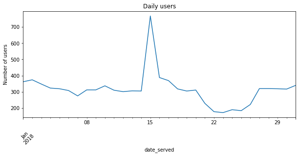

```python
# Plot daily_subscribers
daily_users.plot(figsize=(10,4))

# Include a title and y-axis label
plt.title('Daily users')
plt.ylabel('Number of users')

# Rotate the x-axis labels by 45 degrees
plt.xticks(rotation = 45)

# Display the plot
plt.show()
```

**As you can see the first half of the month sticks around 300 users per day, that's a huge spike in the middle of the month. this maybe because we sent out a big marketing email, which reached many users who are not daily visitors of the site**

# Evaluating how a marketing campaign performed by:

- Conversion Rate Matric to determine how effective a marketing team was at gaining new customers.
- Retention Rate Matric to determine the number of remaining subscribers from the users who converted to the product.

### 1- Conversion Rate Matric

```python
# Calculate the number of people we marketed to
total = marketing['user_id'].nunique()

# Calculate the number of people who subscribed
subscribers = marketing[marketing['converted']== True]['user_id'].nunique()

# Calculate the conversion rate
conversion_rate = subscribers/total
print('number of people we marketed to:',total,
      '\number of people who subscribed:',subscribers)
print(round(conversion_rate*100, 2), "%")
```

```
number of people we marketed to: 7309
umber of people who subscribed: 1015
13.89 %
```

### 2- Retention Rate Matric

```python
# Calculate the number of subscribers
total_subscribers = marketing[marketing['converted']== True]['user_id'].nunique()

# Calculate the number of people who remained subscribed
retained = marketing[marketing['is_retained']== True]['user_id'].nunique()

# Calculate the retention rate
retention_rate = retained/ total_subscribers
print(round(retention_rate*100, 2), "%")
```

```
66.8 %
```

## Customer Segmentation

I'll isolate the data for English speakers and calculate the conversion rate for english speakers to can compare it to the overall conversion rate to gain a sense of how effective the marketing campaign was among this group compared to the overall population.

### 3- Comparing language conversion rate (I)

- to determine how effective the campaign was on converting English speakers.
- determine effectiveness of marketing campaign across the other languages which allows you to determine whether the marketing campaign was more effective in certain languages.

```python
# build a function to calculate conversion rate across any sub-segment I want.
def conversion_rate(dataframe, column_names):
    """ this function takes a DataFrame
    and list of column names and outputs
    the conversion rate across the column(s)
    """

   # Total number of converted users
    column_conv = dataframe[dataframe['converted']== True].groupby(column_names)['user_id'].nunique()

    # Total number users
    column_total = dataframe.groupby(column_names)['user_id'].nunique()

    # Conversion rate
    conversion_rate = column_conv/column_total

    # Fill missing values with 0
    conversion_rate = conversion_rate.fillna(0)
    return conversion_rate
```

```python
# use conversion rate funcation to Calculate conversion rate for English speakers

conversion_rate_english_speakers = conversion_rate(marketing,['language_displayed'])['English']
print('English speaker conversion rate:', round(conversion_rate_english_speakers*100,2), '%')
```

```
English speaker conversion rate: 12.92 %
```

```python
# use conversion rate funcation to Calculate the conversion rate for all languages
language_conversion_rate = conversion_rate(marketing,['language_displayed'])
```

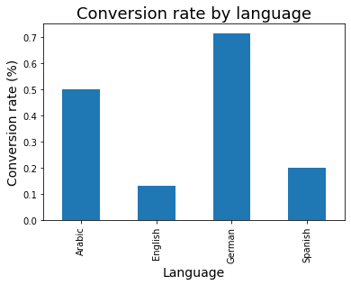

```python
# Create a bar chart using language_conversion_rate DataFrame
language_conversion_rate.plot(kind= 'bar')

# Add a title and x and y-axis labels
plt.title('Conversion rate by language', size = 18)
plt.xlabel('Language', size = 14)
plt.ylabel('Conversion rate (%)', size = 14)

# Display the plot
plt.show()
```

**This plot shows that German and Arabic speakers have much higher conversion rates than English and Spanish speakers.**

```python
# check whether there is any difference in the conversion rate based on when in the month,the users saw an ad.
# use conversion rate funcation to Calculate the conversion rate per day
daily_conversion_rates = conversion_rate(marketing,['date_served'])
daily_conversion_rates.head()
```

```
date_served
2018-01-01    0.099448
2018-01-02    0.098930
2018-01-03    0.103448
2018-01-04    0.108359
2018-01-05    0.125392
Name: user_id, dtype: float64
```

```python
# creating a new DataFrame that includes the conversion rate each day to understand trends over time
# Reset index to turn the results into a DataFrame
daily_conversion_rate = pd.DataFrame(daily_conversion_rates.reset_index())

# Rename columns
daily_conversion_rate.columns = ['date_subscribed', 'conversion_rate']
daily_conversion_rate.head()
```

|  | date_subscribed | conversion_rate |
| --- | --- | --- |
| 0 | 2018-01-01 | 0.099448 |
| 1 | 2018-01-02 | 0.098930 |
| 2 | 2018-01-03 | 0.103448 |
| 3 | 2018-01-04 | 0.108359 |
| 4 | 2018-01-05 | 0.125392 |

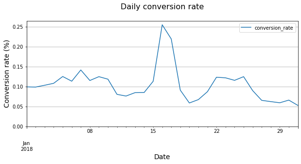

```python
# creating line chart to notice peaks and valleys in our conversion rate over time as well as any overall trends.
plt.figure(figsize=(10,4))

# Create a line chart using daily_conversion_rate
daily_conversion_rate.plot('date_subscribed','conversion_rate', figsize=(10,4))
plt.title('Daily conversion rate\n', size = 16)
plt.ylabel('Conversion rate (%)', size = 14)
plt.xlabel('Date', size = 14)
plt.grid()
# Set the y-axis to begin at 0
plt.ylim(0)

# Display the plot
plt.show()
```

**As you can see, the conversion rate is relatively steady except for one day in January.**

## Marketing channels across age groups

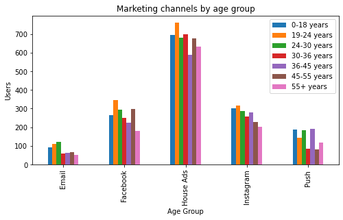

```python
# creating a grouped bar chart showing how many people each marketing channel reached by age group.
channel_age = marketing.groupby(['marketing_channel', 'age_group'])['user_id'].count()

# Unstack channel_age and transform it into a DataFrame
channel_age_df = pd.DataFrame(channel_age.unstack(level = 1))

# Plot channel_age
channel_age_df.plot(kind='bar', figsize = (8,4))

plt.title('Marketing channels by age group')
plt.xlabel('Age Group')
plt.ylabel('Users')

# Add a legend to the plot
plt.legend(loc = 'upper right', labels = channel_age_df.columns.values)

plt.show()
```

## identify how each marketing channel is performing

to know if one channel is outperforming others, it might signal the channel merits further investment.

### By Analyzing retention rates for the campaign

- to determine **which channel had the highest retention rate.**

```python
# create plot funcation to generate plots for sub-segments of the dataset
def plotting_conv(dataframe):
    """generate plots for sub-segments of the dataset"""
    for column in dataframe:
        # Plot column by dataframe's index
        plt.plot(dataframe.index, dataframe[column])
        plt.title('Daily ' + str(column) + ' conversion rate\n',
                  size = 16)
        plt.ylabel('Conversion rate', size = 14)
        plt.xlabel('Date', size = 14)
        plt.xticks(rotation=45)
        # Show plot
        plt.show()
        plt.clf()
```

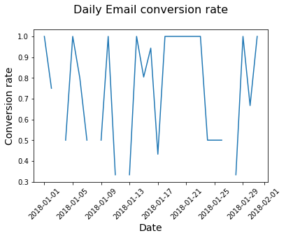

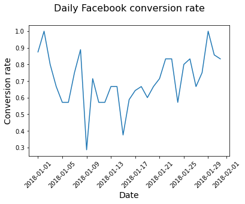

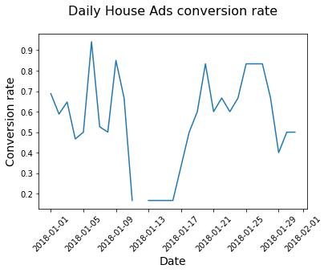

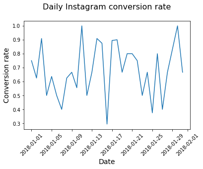

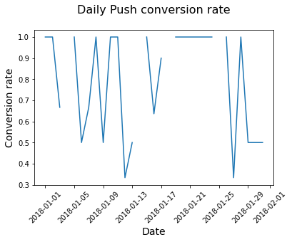

```python
#calculating the retention rate for each subscription channel and visualize your results.

# Count the subs by subscribing channel and day
retention_total = marketing.groupby(['date_subscribed',
                                     'subscribing_channel'])['user_id'].nunique()

# Sum the retained subs by subscribing channel and date subscribed
retention_subs = marketing[marketing['is_retained']== True].groupby(['date_subscribed','subscribing_channel'])['user_id'].nunique()


# Divide retained subscribers by total subscribers
retention_rate = retention_subs/retention_total
retention_rate_df = pd.DataFrame(retention_rate.unstack(level=1))

# plotting retention rate for each subscription
plotting_conv(retention_rate_df)
```

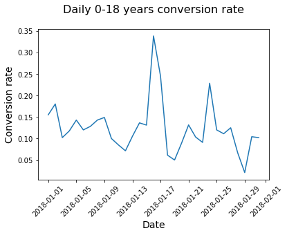

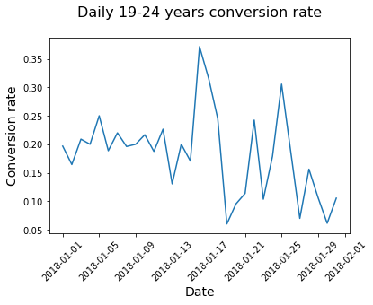

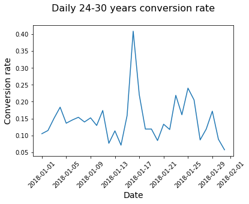

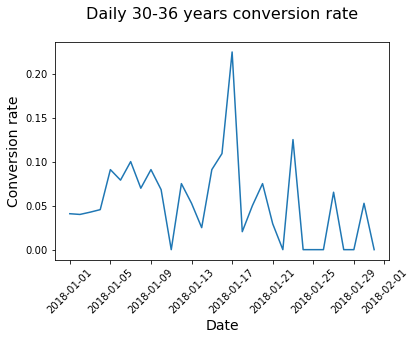

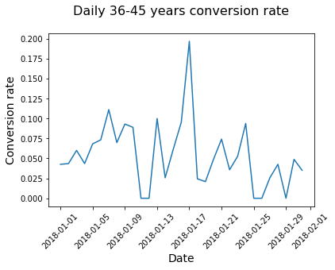

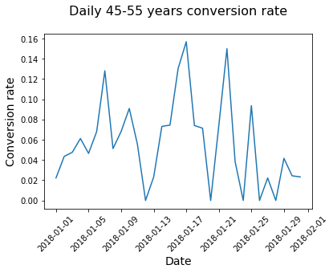

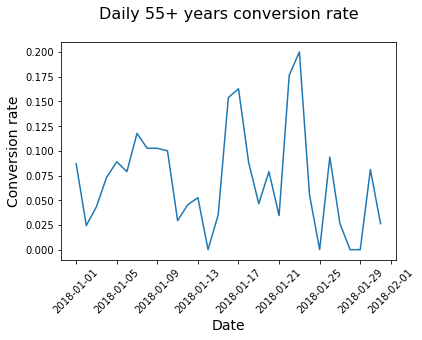

```python
# Calculate conversion rate by date served and age group
age_group_conv = conversion_rate(marketing,['date_served','age_group'])

# Unstack age_group_conv and create a DataFrame
age_group_df = pd.DataFrame(age_group_conv.unstack(level=1))

# Plot the results
plotting_conv(age_group_df)
```

## Investigate house Ad conversion rate

- to determine if there is fluctuations in metric and whether these changes are natural fluctuations or if they require further investigation.

```
date_served  marketing_channel
2018-01-01   Email                1.000000
             Facebook             0.117647
             House Ads            0.084656
             Instagram            0.106667
             Push                 0.083333
Name: user_id, dtype: float64
```

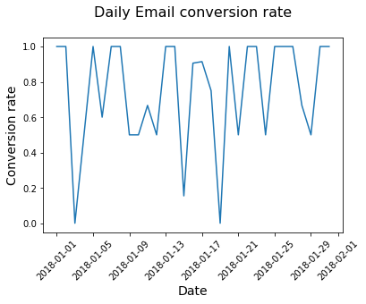

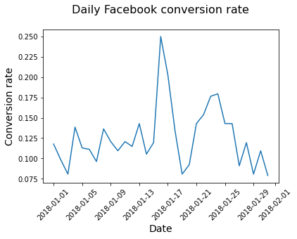

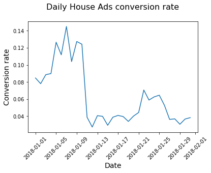

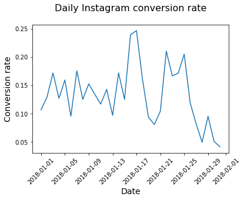

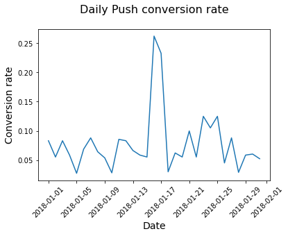

```python
# Calculate conversion rate by date served and channel
daily_conv_channel = conversion_rate(marketing,['date_served','marketing_channel'])

print(daily_conv_channel.head())

# Calculate conversion rate by date served and channel
daily_conv_channel = conversion_rate(marketing, ['date_served',
                                                 'marketing_channel'])

# Unstack daily_conv_channel and convert it to a DataFrame
daily_conv_channel = pd.DataFrame(daily_conv_channel.unstack(level = 1))

# Plot results of daily_conv_channel
plotting_conv(daily_conv_channel)
```

**As we can see, in house ad channel a sudden decrease in conversion rate on 11 january**

## Analyzing House ads conversion rate

- I have confirmed that house ads conversion has been down since January 11, so I will try to identify potential causes for the decrease by checking whether users are more likely to convert on weekends compared with weekdays and determine if that could be the cause for the changing house ads conversion rate.

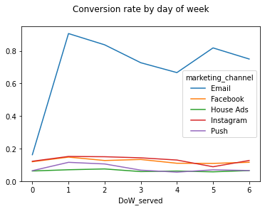

```python
# Add day of week column to marketing
marketing['DoW_served'] = marketing['date_served'].dt.dayofweek

# Calculate conversion rate by day of week
DoW_conversion = conversion_rate(marketing, ['DoW_served', 'marketing_channel'])


# Unstack channels
DoW_df = pd.DataFrame(DoW_conversion.unstack(level=1))

# Plot conversion rate by day of week
DoW_df.plot()
plt.title('Conversion rate by day of week\n')
plt.ylim(0)
plt.show()
```

As you can see, email is particularly high and may be reflective of a tracking error, but house ads appear stable across the week with a slight peak on Tuesday.

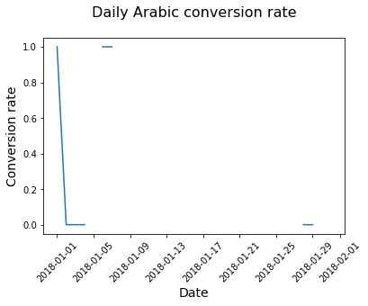

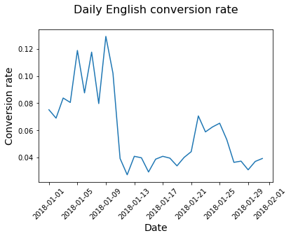

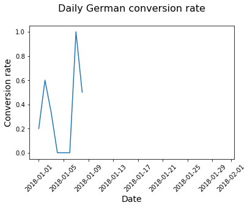

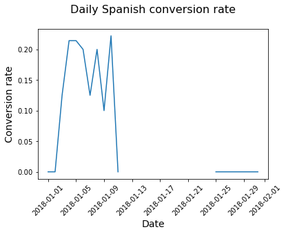

```python
# check House ads conversion by language to detrmine if the marketing campaign apply broadly across different cultures.
# Isolate the rows where marketing channel is House Ads
house_ads = marketing[marketing['marketing_channel'] == 'House Ads']

# Calculate conversion by date served, and language displayed
conv_lang_channel = conversion_rate(house_ads,['date_served', 'language_displayed'])

# Unstack conv_lang_channel
conv_lang_df = pd.DataFrame(conv_lang_channel.unstack(level=1))

# Use your plotting function to display results
plotting_conv(conv_lang_df)
```

As we can see, the English conversion rate drops around the 11th, and there do not appear to be ads served in other languages for a two week period. so I will investigate this problem.

```python
# creating a DataFrame that checks whether users see ads in the correct language

# Add the new column is_correct_lang
house_ads['is_correct_lang'] = np.where(house_ads['language_displayed'] == house_ads['language_preferred'],'Yes','No')

# Groupby date_served and correct_language
language_check = house_ads.groupby(['date_served','is_correct_lang'])['is_correct_lang'].count()

# Unstack language_check and fill missing values with 0's
language_check_df = pd.DataFrame(language_check.unstack(level=1)).fillna(0)

# Print results
language_check_df
```

| is_correct_lang date_served | No | Yes |
| --- | --- | --- |
| 2018-01-01 | 2.0 | 189.0 |
| 2018-01-02 | 3.0 | 247.0 |
| 2018-01-03 | 0.0 | 220.0 |
| 2018-01-04 | 0.0 | 168.0 |
| 2018-01-05 | 0.0 | 160.0 |
| 2018-01-06 | 1.0 | 151.0 |
| 2018-01-07 | 2.0 | 130.0 |
| 2018-01-08 | 0.0 | 154.0 |
| 2018-01-09 | 0.0 | 157.0 |
| 2018-01-10 | 0.0 | 170.0 |
| 2018-01-11 | 20.0 | 135.0 |
| 2018-01-12 | 18.0 | 130.0 |
| 2018-01-13 | 26.0 | 122.0 |
| 2018-01-14 | 20.0 | 131.0 |
| 2018-01-15 | 16.0 | 192.0 |
| 2018-01-16 | 28.0 | 127.0 |
| 2018-01-17 | 21.0 | 127.0 |
| 2018-01-18 | 31.0 | 121.0 |
| 2018-01-19 | 22.0 | 127.0 |
| 2018-01-20 | 28.0 | 124.0 |
| 2018-01-21 | 14.0 | 100.0 |
| 2018-01-22 | 13.0 | 72.0 |
| 2018-01-23 | 16.0 | 69.0 |
| 2018-01-24 | 13.0 | 83.0 |
| 2018-01-25 | 19.0 | 74.0 |
| 2018-01-26 | 24.0 | 92.0 |
| 2018-01-27 | 18.0 | 149.0 |
| 2018-01-28 | 28.0 | 136.0 |
| 2018-01-29 | 24.0 | 142.0 |
| 2018-01-30 | 23.0 | 145.0 |
| 2018-01-31 | 23.0 | 135.0 |

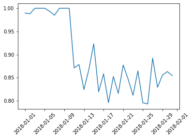

```python
# calculating the percentage of users were not being served ads in the right language and plot your results.
# Divide the count where language is correct by the row sum
language_check_df['pct'] = language_check_df['Yes']/language_check_df.sum(axis=1)

# Plot and show your results
plt.plot(language_check_df.index.values, language_check_df['pct'])
plt.xticks(rotation=45)
plt.show()
```

**as we can see,the house ads have been underperforming due to serving all ads in English rather than each user's preferred language**

## Assing the impact of users were seeing ads in languages other than there preferred language to know how many subscribers they lost as a result of this bug.

```python
# creating indexes for each language compared with English, to can assess
# what conversion rate should have been during the rest of the month

# Calculate pre-error conversion rate
house_ads_bug = house_ads[house_ads['date_served'] < '2018-01-11']
lang_conv = conversion_rate(house_ads_bug, ['language_displayed'])

# Index other language conversion rate against English
spanish_index = lang_conv['Spanish']/lang_conv['English']
arabic_index = lang_conv['Arabic']/ lang_conv['English']
german_index = lang_conv['German']/ lang_conv['English']

print("Spanish index:", spanish_index)
print("Arabic index:", arabic_index)
print("German index:", german_index)
```

```
Spanish index: 1.681924882629108
Arabic index: 5.045774647887324
German index: 4.485133020344287
```

## Analyzing user preferences

```python
# create a new DataFrame that you can perform calculations on to determine
# the expected number of subscribers if there had there been no language error
# The DataFrame will include how many users prefer each language by day.

# Group house_ads by date and language
converted = house_ads.groupby(['date_served','language_preferred']).agg({'user_id':'nunique','converted':'sum'})
converted

# Unstack converted
converted_df = pd.DataFrame(converted.unstack(level = 1))
print(converted_df.info())
converted_df.head()
```

```
<class 'pandas.core.frame.DataFrame'>
DatetimeIndex: 31 entries, 2018-01-01 to 2018-01-31
Data columns (total 8 columns):
 #   Column                Non-Null Count  Dtype
---  ------                --------------  -----
 0   (user_id, Arabic)     27 non-null     float64
 1   (user_id, English)    31 non-null     float64
 2   (user_id, German)     30 non-null     float64
 3   (user_id, Spanish)    31 non-null     float64
 4   (converted, Arabic)   27 non-null     object
 5   (converted, English)  31 non-null     object
 6   (converted, German)   30 non-null     object
 7   (converted, Spanish)  31 non-null     object
dtypes: float64(4), object(4)
memory usage: 2.2+ KB
None
```

| language_preferred date_served | user_id Arabic | user_id English | user_id German | user_id Spanish | converted Arabic | converted English | converted German | converted Spanish |
| --- | --- | --- | --- | --- | --- | --- | --- | --- |
| 2018-01-01 | 2.0 | 171.0 | 5.0 | 11.0 | 2 | 13 | 1 | 0 |
| 2018-01-02 | 3.0 | 200.0 | 5.0 | 10.0 | 0 | 14 | 3 | 0 |
| 2018-01-03 | 2.0 | 179.0 | 3.0 | 8.0 | 0 | 15 | 1 | 1 |
| 2018-01-04 | 2.0 | 149.0 | 2.0 | 14.0 | 0 | 12 | 0 | 3 |
| 2018-01-05 | NaN | 143.0 | 1.0 | 14.0 | NaN | 17 | False | 3 |

```python
# building out a DataFrame that will estimate what daily conversion rates
# should have been if users were being served the correct language.

# Create English conversion rate column for affected period
converted_df['english_conv_rate'] = converted_df.loc['2018-01-11': '2018-01-31'][('converted','English')]

# Create expected conversion rates for each language
converted_df['expected_spanish_rate'] = converted_df['english_conv_rate']*spanish_index
converted_df['expected_arabic_rate'] = converted_df['english_conv_rate']*arabic_index
converted_df['expected_german_rate'] = converted_df['english_conv_rate']*german_index

# Multiply number of users by the expected conversion rate
converted_df['expected_spanish_conv'] = converted_df['expected_spanish_rate']/100*converted_df[('user_id','Spanish')]
converted_df['expected_arabic_conv'] = converted_df['expected_arabic_rate']/100*converted_df[('user_id','Arabic')]
converted_df['expected_german_conv'] = converted_df['expected_german_rate']/100*converted_df[('user_id','German')]

converted_df.head(12)
```

| language_preferred date_served | user_id Arabic | user_id English | user_id German | user_id Spanish | converted Arabic | converted English | converted German | converted Spanish | english_conv_rate | expected_spanish_rate | expected_arabic_rate | expected_german_rate | expected_spanish_conv | expected_arabic_conv | expected_german_conv |
| --- | --- | --- | --- | --- | --- | --- | --- | --- | --- | --- | --- | --- | --- | --- | --- |
| 2018-01-01 | 2.0 | 171.0 | 5.0 | 11.0 | 2 | 13 | 1 | 0 | NaN | NaN | NaN | NaN | NaN | NaN | NaN |
| 2018-01-02 | 3.0 | 200.0 | 5.0 | 10.0 | 0 | 14 | 3 | 0 | NaN | NaN | NaN | NaN | NaN | NaN | NaN |
| 2018-01-03 | 2.0 | 179.0 | 3.0 | 8.0 | 0 | 15 | 1 | 1 | NaN | NaN | NaN | NaN | NaN | NaN | NaN |
| 2018-01-04 | 2.0 | 149.0 | 2.0 | 14.0 | 0 | 12 | 0 | 3 | NaN | NaN | NaN | NaN | NaN | NaN | NaN |
| 2018-01-05 | NaN | 143.0 | 1.0 | 14.0 | NaN | 17 | False | 3 | NaN | NaN | NaN | NaN | NaN | NaN | NaN |
| 2018-01-06 | 3.0 | 136.0 | 2.0 | 11.0 | 3 | 12 | 0 | 2 | NaN | NaN | NaN | NaN | NaN | NaN | NaN |
| 2018-01-07 | 2.0 | 117.0 | 2.0 | 10.0 | 2 | 14 | 2 | 1 | NaN | NaN | NaN | NaN | NaN | NaN | NaN |
| 2018-01-08 | NaN | 138.0 | 6.0 | 10.0 | NaN | 11 | 3 | 2 | NaN | NaN | NaN | NaN | NaN | NaN | NaN |
| 2018-01-09 | NaN | 147.0 | NaN | 10.0 | NaN | 19 | NaN | 1 | NaN | NaN | NaN | NaN | NaN | NaN | NaN |
| 2018-01-10 | NaN | 147.0 | 4.0 | 18.0 | NaN | 15 | 2 | 4 | NaN | NaN | NaN | NaN | NaN | NaN | NaN |
| 2018-01-11 | 7.0 | 133.0 | 2.0 | 13.0 | 0 | 6 | 0 | 0 | 6 | 10.091549 | 30.274648 | 26.910798 | 1.311901 | 2.119225 | 0.538216 |
| 2018-01-12 | 3.0 | 129.0 | 4.0 | 11.0 | 0 | 3 | 0 | 1 | 3 | 5.045775 | 15.137324 | 13.455399 | 0.555035 | 0.45412 | 0.538216 |

you will assess how many subscribers you lost due to the language discrepancy.

```python
# Use .loc to slice only the relevant dates
converted = converted_df.loc['2018-01-11':'2018-01-31']

# Sum expected subscribers for each language
expected_subs = converted['expected_spanish_conv'].sum() + converted['expected_arabic_conv'].sum() + converted['expected_german_conv'].sum()

# Calculate how many subscribers we actually got
actual_subs = converted[('converted','Spanish')].sum() + converted[('converted','Arabic')].sum() + converted[('converted','German')].sum()

# Subtract how many subscribers we got despite the bug
lost_subs = expected_subs - actual_subs
print(lost_subs)
```

```
32.144143192488265
```

**32 subscribers may not seem like many, but for a small company this can be vitally important, especially when expanding to new markets.**

### The email portion of this campaign was actually run as an A/B test. Half the emails sent out were generic upsells to your product while the other half contained personalized messaging around the users’ usage of the site.

> so I am going to look at the conversion rate for the control and personalization. Since we chose conversion rate as our key metrics for this test, so I'll evaluate whether or not conversion was higher in the personalization treatment compared with the control.

### Test allocation

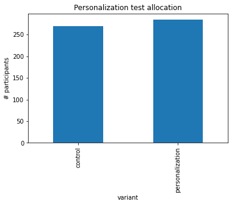

```python
#checking if the users were allocated equally to the test and control groups.

# Subset the DataFrame
email = marketing[marketing['marketing_channel']== 'Email']

# Group the email DataFrame by variant
alloc = email.groupby('variant')['user_id'].nunique()

# Plot a bar chart of the test allocation
alloc.plot(kind='bar')
plt.title('Personalization test allocation')
plt.ylabel('# participants')
plt.show()
```

**There's a slight difference in allocation, but it's within the expected range so I will continue with analysis.**

### Comparing conversion rates

```python
# checking the conversion rate for the control and personalization to evaluate whether or
# not conversion was higher in the personalization treatment compared with the control.

# Group marketing by user_id and variant
subscribers = email.groupby(['user_id','variant'])['converted'].max()
subscribers_df = pd.DataFrame(subscribers.unstack(level=1))
subscribers_df

# Drop missing values from the control column
control = subscribers_df['control'].dropna()

# Drop missing values from the personalization column
personalization = subscribers_df['personalization'].dropna()

print('Control conversion rate:', np.mean(control))
print('Personalization conversion rate:', np.mean(personalization))
```

```
Control conversion rate: 0.2814814814814815
Personalization conversion rate: 0.3908450704225352
```

**as we can see that personalization converted users at a higher rate than the control. So, I will build a lift function to quantify by how much.**

#### Creating lift funcation by calculating the difference between the treatment effect (or the mean) of the treatment compared to the treatment effect of the control divided by the treatment effect of the control.

```python
# create a lift function to automate the process of calculating lift.
def lift(a,b):
    # Calcuate the mean of a and b
    control_mean = np.mean(control)
    personalization_mean = np.mean(personalization)

    # Calculate the lift using a_mean and b_mean
    lift = (personalization_mean-control_mean)/control_mean

    return str(round(lift*100, 2)) + '%'

# Print lift() with control and personalization as inputs
print(lift(control, personalization))
```

```
38.85%
```

### there's a large lift, which is mean the personalization variant outperformed the control

> so I will determine whether the result is statistically significant using T-test. to understanding whether a test showed a positive result by chance or if it is reflective of a true difference between the variants

```python
from scipy.stats import ttest_ind
t = ttest_ind(control,personalization)
t
```

```
Ttest_indResult(statistic=-2.7343299447505074, pvalue=0.006451487844694175)
```

**p = 0.006. less than 0.05 so The personalization results are highly statistically significant.**

### Building an A/B test segmenting function

> I will build funcation to segment data to check how new features are affecting specific demographics. Sometimes features that are highly appealing to one group are less appealing to others

```python
def ab_segmentation(segment):
    """this funcation analyzes the impact of A/B tests
    on segments of data that can reuse each time I
    want to conduct this kind of analysis.
    """
    # Build a for loop for each subsegment in marketing
    for subsegment in np.unique(marketing[segment].values):
        print(subsegment)

      # Limit marketing to email and subsegment
        email = marketing[(marketing['marketing_channel'] == 'Email') & (marketing[segment] == subsegment)]

        subscribers = email.groupby(['user_id', 'variant'])['converted'].max()
        subscribers = pd.DataFrame(subscribers.unstack(level=1))
        control = subscribers['control'].dropna()
        personalization = subscribers['personalization'].dropna()

        print('lift:', lift(control, personalization))
        print('t-statistic:', ttest_ind(control,personalization), '\n\n')
```

Often a treatment will not affect all people uniformly. So, I will run through two segments in our data that may be relevant to assessing the impact of our test.

- 1st group 'language_displayed'
- 2nd group 'age group'.

```python
# Use ab_segmentation on language displayed
ab_segmentation('language_displayed')
```

```
Arabic
lift: 38.85%
t-statistic: Ttest_indResult(statistic=-0.5773502691896255, pvalue=0.5795840000000001)


English
lift: 38.85%
t-statistic: Ttest_indResult(statistic=-2.2183598646203166, pvalue=0.026991701290720815)


German
lift: 38.85%
t-statistic: Ttest_indResult(statistic=0.1910083418078718, pvalue=0.8494394170062678)


Spanish
lift: 38.85%
t-statistic: Ttest_indResult(statistic=-2.3570226039551585, pvalue=0.040156718110477524)
```

**As we can see the personalization is only effective with English and Spanish speakers while other languges not statistically signficant**

```python
# Use ab_segmentation on age group
ab_segmentation('age_group')
```

```
0-18 years
lift: 38.85%
t-statistic: Ttest_indResult(statistic=-2.966044912142211, pvalue=0.0038724494391297226)


19-24 years
lift: 38.85%
t-statistic: Ttest_indResult(statistic=-3.03179438478667, pvalue=0.0030623836114689134)


24-30 years
lift: 38.85%
t-statistic: Ttest_indResult(statistic=-3.861539544326876, pvalue=0.00018743381094867337)


30-36 years
lift: 38.85%
t-statistic: Ttest_indResult(statistic=3.1859064644147996, pvalue=0.0023238487431765137)


36-45 years
lift: 38.85%
t-statistic: Ttest_indResult(statistic=2.4317901279318503, pvalue=0.01797568600978829)


45-55 years
lift: 38.85%
t-statistic: Ttest_indResult(statistic=2.065499127317933, pvalue=0.043062339688201196)


55+ years
lift: 38.85%
t-statistic: Ttest_indResult(statistic=3.3265654564203397, pvalue=0.0016358623456360435)
```

**I found that personalization was extremely effective for younger groups but less effective than the control for older groups. One explanation might be that younger users understand how their data might be used online and think personalization is cool because it gives them more insight into themselves while older people might feel that this is a violation of their privacy.**